# Part I - Exploring San Francisco Bay Area’s Bike Share Data

## Introduction

> This document analyses information about individual rides made in a bike-sharing system covering the greater San Francisco Bay area.

## Preliminary Wrangling

> For me to be able to give a good visualisation, I will perform alittle data wrangling in the dataset. Let's first begin by loading in the dataset.

```python
# at the top of the file, before other imports
import warnings

warnings.filterwarnings('ignore')

# no warnings will be printed from now on.
```

```python
# import all packages and set plots to be embedded inline
import pandas as pd
import matplotlib.pyplot as plt
import seaborn as sb
import numpy as np

%matplotlib inline
```

> Load in your dataset and describe its properties through the questions below. Try and motivate your exploration goals through this section.

```python
# load in the dataset into a pandas dataframe, print statistics
fordgobike = pd.read_csv('201902-fordgobike-tripdata.csv')
```

```python
# Lets first commence by inspecting our data
print(fordgobike.shape)
print(fordgobike.dtypes)
print(fordgobike.head(5))
```

```
(183412, 16)
duration_sec                 int64
start_time                  object
end_time                    object
start_station_id           float64
start_station_name          object
start_station_latitude     float64
start_station_longitude    float64
end_station_id             float64
end_station_name            object
end_station_latitude       float64
end_station_longitude      float64
bike_id                      int64
user_type                   object
member_birth_year          float64
member_gender               object
bike_share_for_all_trip     object
dtype: object
   duration_sec                start_time                  end_time  \
0         52185  2019-02-28 17:32:10.1450  2019-03-01 08:01:55.9750
1         42521  2019-02-28 18:53:21.7890  2019-03-01 06:42:03.0560
2         61854  2019-02-28 12:13:13.2180  2019-03-01 05:24:08.1460
3         36490  2019-02-28 17:54:26.0100  2019-03-01 04:02:36.8420
4          1585  2019-02-28 23:54:18.5490  2019-03-01 00:20:44.0740

   start_station_id                                start_station_name  \
0              21.0  Montgomery St BART Station (Market St at 2nd St)
1              23.0                     The Embarcadero at Steuart St
2              86.0                           Market St at Dolores St
3             375.0                           Grove St at Masonic Ave
4               7.0                               Frank H Ogawa Plaza

   start_station_latitude  start_station_longitude  end_station_id  \
0               37.789625              -122.400811            13.0
1               37.791464              -122.391034            81.0
2               37.769305              -122.426826             3.0
3               37.774836              -122.446546            70.0
4               37.804562              -122.271738           222.0

                               end_station_name  end_station_latitude  \
0                Commercial St at Montgomery St             37.794231
1                            Berry St at 4th St             37.775880
2  Powell St BART Station (Market St at 4th St)             37.786375
3                        Central Ave at Fell St             37.773311
4                         10th Ave at E 15th St             37.792714

   end_station_longitude  bike_id   user_type  member_birth_year  \
0            -122.402923     4902    Customer             1984.0
1            -122.393170     2535    Customer                NaN
2            -122.404904     5905    Customer             1972.0
3            -122.444293     6638  Subscriber             1989.0
4            -122.248780     4898  Subscriber             1974.0

  member_gender bike_share_for_all_trip
0          Male                      No
1           NaN                      No
2          Male                      No
3         Other                      No
4          Male                     Yes
```

```python
# Lets check the value_counts for the end_stations.
fordgobike.end_station_name.value_counts()
```

```
San Francisco Caltrain Station 2  (Townsend St at 4th St)          4857
Market St at 10th St                                               3973
Montgomery St BART Station (Market St at 2nd St)                   3647
San Francisco Ferry Building (Harry Bridges Plaza)                 3368
Powell St BART Station (Market St at 4th St)                       2997
San Francisco Caltrain (Townsend St at 4th St)                     2947
Berry St at 4th St                                                 2872
The Embarcadero at Sansome St                                      2512
Powell St BART Station (Market St at 5th St)                       2353
Steuart St at Market St                                            2338
Howard St at Beale St                                              2034
Civic Center/UN Plaza BART Station (Market St at McAllister St)    1865
Bancroft Way at Telegraph Ave                                      1814
Beale St at Harrison St                                            1812
2nd St at Townsend St                                              1741
3rd St at Townsend St                                              1700
Embarcadero BART Station (Beale St at Market St)                   1699
4th St at Mission Bay Blvd S                                       1626
Townsend St at 7th St                                              1540
The Embarcadero at Steuart St                                      1447
19th Street BART Station                                           1430
Post St at Kearny St                                               1422
Downtown Berkeley BART                                             1380
Rhode Island St at 17th St                                         1345
8th St at Brannan St                                               1331
Folsom St at 3rd St                                                1302
Howard St at 8th St                                                1284
Esprit Park                                                        1266
4th St at 16th St                                                  1208
Spear St at Folsom St                                              1164
                                                                   ...
San Carlos St at Market St                                           52
Williams Ave at 3rd St                                               51
27th St at MLK Jr Way                                                49
Market St at 40th St                                                 49
Empire St at 1st St                                                  47
Lane St at Revere Ave                                                46
Locust St at Grant St                                                45
SAP Center                                                           42
Almaden Blvd at Balbach St                                           38
Bestor Art Park                                                      38
10th Ave at E 15th St                                                37
George St at 1st St                                                  34
San Pedro St at Hedding St                                           30
Empire St at 7th St                                                  28
Oak St at 1st St                                                     28
Mission St at 1st St                                                 25
Backesto Park (Jackson St at 13th St)                                21
Williams Ave at Apollo St                                            20
Farnam St at Fruitvale Ave                                           20
Foothill Blvd at 42nd Ave                                            20
23rd Ave at Foothill Blvd                                            20
26th Ave at International Blvd                                       19
Foothill Blvd at Harrington Ave                                      16
Leavenworth St at Broadway                                           12
Taylor St at 9th St                                                  11
Parker Ave at McAllister St                                           9
Palm St at Willow St                                                  7
16th St Depot                                                         6
21st Ave at International Blvd                                        6
Willow St at Vine St                                                  5
Name: end_station_name, Length: 329, dtype: int64
```

### What is the structure of your dataset?

> There are 183412 rows with 16 columns in the dataset. There are 9 variables that are numeric in nature and 7 that are categorical. Besides the start_time and end_time being categorized as strings instead the datetime dtypes, all the other categorical variables (start_station_name, end_station_name, member_gender, and bike_share_for_all_trips) are nominal variables.

### What is/are the main feature(s) of interest in your dataset?

> 1. I’m most interested in figuring out when are most trips taken in terms of the day of the week.
> 2. I’m also interested in figuring out how long does the average trip take.
> 3. Finally, I’m also interested in figuring out if the above depend on if a user is a subscriber or customer and also based on the gender.

### What features in the dataset do you think will help support your investigation into your feature(s) of interest?

> I expect that the duration in which trips are made will play a big part in this analysis. Time, day and month will also have a very strong effect on each trip made: Each trip is made in a particular day of the month. I also think that the user_type, member_gender, start_weekday and the member_birth_year will have effects on the duration of the bikeshare.

## Data Wrangling

Let’s begin by doing a little modification to the dataset since it contains some flaws. By doing this our dataset will be set and ready to commence visualization.

```python
# Let's start by making a copy of the original dataset for us to retain the original version.

bike_df = fordgobike.copy()
bike_df.head()
```

|  | duration_sec | start_time | end_time | start_station_id | start_station_name | start_station_latitude | start_station_longitude | end_station_id | end_station_name | end_station_latitude | end_station_longitude | bike_id | user_type | member_birth_year | member_gender | bike_share_for_all_trip |
| --- | --- | --- | --- | --- | --- | --- | --- | --- | --- | --- | --- | --- | --- | --- | --- | --- |
| 0 | 52185 | 2019-02-28 17:32:10.1450 | 2019-03-01 08:01:55.9750 | 21.0 | Montgomery St BART Station (Market St at 2nd St) | 37.789625 | -122.400811 | 13.0 | Commercial St at Montgomery St | 37.794231 | -122.402923 | 4902 | Customer | 1984.0 | Male | No |
| 1 | 42521 | 2019-02-28 18:53:21.7890 | 2019-03-01 06:42:03.0560 | 23.0 | The Embarcadero at Steuart St | 37.791464 | -122.391034 | 81.0 | Berry St at 4th St | 37.775880 | -122.393170 | 2535 | Customer | NaN | NaN | No |
| 2 | 61854 | 2019-02-28 12:13:13.2180 | 2019-03-01 05:24:08.1460 | 86.0 | Market St at Dolores St | 37.769305 | -122.426826 | 3.0 | Powell St BART Station (Market St at 4th St) | 37.786375 | -122.404904 | 5905 | Customer | 1972.0 | Male | No |
| 3 | 36490 | 2019-02-28 17:54:26.0100 | 2019-03-01 04:02:36.8420 | 375.0 | Grove St at Masonic Ave | 37.774836 | -122.446546 | 70.0 | Central Ave at Fell St | 37.773311 | -122.444293 | 6638 | Subscriber | 1989.0 | Other | No |
| 4 | 1585 | 2019-02-28 23:54:18.5490 | 2019-03-01 00:20:44.0740 | 7.0 | Frank H Ogawa Plaza | 37.804562 | -122.271738 | 222.0 | 10th Ave at E 15th St | 37.792714 | -122.248780 | 4898 | Subscriber | 1974.0 | Male | Yes |

```python
# Let's check the dtypes in the dataframe.
bike_df.dtypes
```

```
duration_sec                 int64
start_time                  object
end_time                    object
start_station_id           float64
start_station_name          object
start_station_latitude     float64
start_station_longitude    float64
end_station_id             float64
end_station_name            object
end_station_latitude       float64
end_station_longitude      float64
bike_id                      int64
user_type                   object
member_birth_year          float64
member_gender               object
bike_share_for_all_trip     object
dtype: object
```

```python
#Since we will not be using the bike_share_for_all_trip, lets drop the collumn using the drop function.
bike_df = bike_df.drop(labels = ['bike_share_for_all_trip'], axis = 1)
```

### Test

```python
bike_df.shape
```

```
(183412, 15)
```

I've already noticed a few things about the data from a quick look at the csv. First, the station data is repeated, there's a station ID, name, latitude, and longitude in every entry. Second, I noticed that I'm going to need the time/date stamp split up into date, time, and day of the week. While I could keep running the functions everytime I need them, it would be easier if they were by themselves.

```python
bike_df.info()
```

```
<class 'pandas.core.frame.DataFrame'>
RangeIndex: 183412 entries, 0 to 183411
Data columns (total 15 columns):
duration_sec               183412 non-null int64
start_time                 183412 non-null object
end_time                   183412 non-null object
start_station_id           183215 non-null float64
start_station_name         183215 non-null object
start_station_latitude     183412 non-null float64
start_station_longitude    183412 non-null float64
end_station_id             183215 non-null float64
end_station_name           183215 non-null object
end_station_latitude       183412 non-null float64
end_station_longitude      183412 non-null float64
bike_id                    183412 non-null int64
user_type                  183412 non-null object
member_birth_year          175147 non-null float64
member_gender              175147 non-null object
dtypes: float64(7), int64(2), object(6)
memory usage: 21.0+ MB
```

Apparently there's something else; start and end times should be time date. When spliting up the date/time, I'll have to see if they ever go over more than one calander day.

I will also change the station IDs to integers.

Let's have a look at the non-null values in our dataset.

```python
for col in bike_df.columns:
    print(col + ' non-null: ' + str(bike_df[col].count()))
```

```
duration_sec non-null: 183412
start_time non-null: 183412
end_time non-null: 183412
start_station_id non-null: 183215
start_station_name non-null: 183215
start_station_latitude non-null: 183412
start_station_longitude non-null: 183412
end_station_id non-null: 183215
end_station_name non-null: 183215
end_station_latitude non-null: 183412
end_station_longitude non-null: 183412
bike_id non-null: 183412
user_type non-null: 183412
member_birth_year non-null: 175147
member_gender non-null: 175147
```

Why are there missing member_birth_year, and member_gender values but no missing station latitude and longitude?

```python
bike_df.describe()
```

|  | duration_sec | start_station_id | start_station_latitude | start_station_longitude | end_station_id | end_station_latitude | end_station_longitude | bike_id | member_birth_year |
| --- | --- | --- | --- | --- | --- | --- | --- | --- | --- |
| count | 183412.000000 | 183215.000000 | 183412.000000 | 183412.000000 | 183215.000000 | 183412.000000 | 183412.000000 | 183412.000000 | 175147.000000 |
| mean | 726.078435 | 138.590427 | 37.771223 | -122.352664 | 136.249123 | 37.771427 | -122.352250 | 4472.906375 | 1984.806437 |
| std | 1794.389780 | 111.778864 | 0.099581 | 0.117097 | 111.515131 | 0.099490 | 0.116673 | 1664.383394 | 10.116689 |
| min | 61.000000 | 3.000000 | 37.317298 | -122.453704 | 3.000000 | 37.317298 | -122.453704 | 11.000000 | 1878.000000 |
| 25% | 325.000000 | 47.000000 | 37.770083 | -122.412408 | 44.000000 | 37.770407 | -122.411726 | 3777.000000 | 1980.000000 |
| 50% | 514.000000 | 104.000000 | 37.780760 | -122.398285 | 100.000000 | 37.781010 | -122.398279 | 4958.000000 | 1987.000000 |
| 75% | 796.000000 | 239.000000 | 37.797280 | -122.286533 | 235.000000 | 37.797320 | -122.288045 | 5502.000000 | 1992.000000 |
| max | 85444.000000 | 398.000000 | 37.880222 | -121.874119 | 398.000000 | 37.880222 | -121.874119 | 6645.000000 | 2001.000000 |

```python
bike_df.nunique()
```

```
duration_sec                 4752
start_time                 183401
end_time                   183397
start_station_id              329
start_station_name            329
start_station_latitude        334
start_station_longitude       335
end_station_id                329
end_station_name              329
end_station_latitude          335
end_station_longitude         335
bike_id                      4646
user_type                       2
member_birth_year              75
member_gender                   3
dtype: int64
```

Let's now look at the time intervals.

```python
print('Number 1 second or more: ' + str(bike_df[bike_df['duration_sec'] > 0].shape[0]))
print('Number 1 minute or more: ' + str(bike_df[bike_df['duration_sec'] > 60].shape[0]))
print('Number 1 hour or more: ' + str(bike_df[bike_df['duration_sec'] > 3600].shape[0]))
print('Number 1 day or more: ' + str(bike_df[bike_df['duration_sec'] > 86400].shape[0]))
print('Number 1 week or more: ' + str(bike_df[bike_df['duration_sec'] > 604800].shape[0]))
```

```
Number 1 second or more: 183412
Number 1 minute or more: 183412
Number 1 hour or more: 1710
Number 1 day or more: 0
Number 1 week or more: 0
```

Having no issue with duplicates eases up our data set to have accurate visualizations.

### Task list:

1. Change start and end times to date time.
2. Drop the duplicated stations
3. Get the data, time, and day of the week into seperate columns (I will have to change the original column title from time to time_stamp).
4. Fill in the Nan values in the member_gender column.
5. Create a dataframe with the station data (for easy look up of data).

### Cleaning

I'm going to start by first changing start and end time to data/time.

```python
bike_df['start_time'] = pd.to_datetime(bike_df['start_time'])
bike_df['end_time'] = pd.to_datetime(bike_df['end_time'])
bike_df.dtypes
```

```
duration_sec                        int64
start_time                 datetime64[ns]
end_time                   datetime64[ns]
start_station_id                  float64
start_station_name                 object
start_station_latitude            float64
start_station_longitude           float64
end_station_id                    float64
end_station_name                   object
end_station_latitude              float64
end_station_longitude             float64
bike_id                             int64
user_type                          object
member_birth_year                 float64
member_gender                      object
dtype: object
```

Secondly, lets sort out the duplicated station namesby using drop function.

```python
# Looking into duplicate station names.
stations = bike_df[['start_station_id', 'start_station_name']].drop_duplicates()
stations.shape
```

```
(330, 2)
```

```python
station_name_count = stations[['start_station_id', 'start_station_name']].groupby('start_station_id').agg('count')
station_name_count.shape
```

```
(329, 1)
```

```python
# Now lets remove the duplicates
station_name_dup = station_name_count[station_name_count['start_station_name'] > 1]
station_name_dup.shape
```

```
(0, 1)
```

Now time to split out the time. But first let's change to a more appropriate name.

```python
# Lets change the names
bike_df.rename(columns = {'start_time':'start_timestamp', 'end_time':'end_timestamp'}, inplace = True)

#Now lets split the time
bike_df['start_date'] = bike_df['start_timestamp'].dt.date
bike_df['start_time'] = bike_df['start_timestamp'].dt.time
bike_df['start_weekday'] = bike_df['start_timestamp'].dt.weekday
bike_df['end_date'] = bike_df['end_timestamp'].dt.date
bike_df['end_time'] = bike_df['end_timestamp'].dt.time
bike_df['end_weekday'] = bike_df['end_timestamp'].dt.weekday
bike_df.dtypes
```

```
duration_sec                        int64
start_timestamp            datetime64[ns]
end_timestamp              datetime64[ns]
start_station_id                  float64
start_station_name                 object
start_station_latitude            float64
start_station_longitude           float64
end_station_id                    float64
end_station_name                   object
end_station_latitude              float64
end_station_longitude             float64
bike_id                             int64
user_type                          object
member_birth_year                 float64
member_gender                      object
start_date                         object
start_time                         object
start_weekday                       int64
end_date                           object
end_time                           object
end_weekday                         int64
dtype: object
```

```python
bike_df.sample(20)
```

|  | duration_sec | start_timestamp | end_timestamp | start_station_id | start_station_name | start_station_latitude | start_station_longitude | end_station_id | end_station_name | end_station_latitude | ... | bike_id | user_type | member_birth_year | member_gender | start_date | start_time | start_weekday | end_date | end_time | end_weekday |
| --- | --- | --- | --- | --- | --- | --- | --- | --- | --- | --- | --- | --- | --- | --- | --- | --- | --- | --- | --- | --- | --- |
| 68951 | 450 | 2019-02-19 20:37:42.898 | 2019-02-19 20:45:13.188 | 193.0 | Grand Ave at Santa Clara Ave | 37.812744 | -122.247215 | 181.0 | Grand Ave at Webster St | 37.811377 | ... | 2471 | Customer | NaN | NaN | 2019-02-19 | 20:37:42.898000 | 1 | 2019-02-19 | 20:45:13.188000 | 1 |
| 89789 | 532 | 2019-02-16 14:35:43.704 | 2019-02-16 14:44:36.279 | 279.0 | Santa Clara St at 7th St | 37.339146 | -121.884105 | 305.0 | Ryland Park | 37.342725 | ... | 6346 | Subscriber | 1999.0 | Male | 2019-02-16 | 14:35:43.704000 | 5 | 2019-02-16 | 14:44:36.279000 | 5 |
| 68257 | 580 | 2019-02-20 01:59:19.572 | 2019-02-20 02:09:00.025 | 175.0 | 49th St at Telegraph Ave | 37.835946 | -122.262366 | 156.0 | Stanford Ave at Hollis St | 37.838443 | ... | 4916 | Subscriber | 1980.0 | Male | 2019-02-20 | 01:59:19.572000 | 2 | 2019-02-20 | 02:09:00.025000 | 2 |
| 166671 | 444 | 2019-02-04 18:23:33.979 | 2019-02-04 18:30:58.306 | 96.0 | Dolores St at 15th St | 37.766210 | -122.426614 | 75.0 | Market St at Franklin St | 37.773793 | ... | 283 | Subscriber | 1987.0 | Male | 2019-02-04 | 18:23:33.979000 | 0 | 2019-02-04 | 18:30:58.306000 | 0 |
| 16395 | 234 | 2019-02-27 08:37:36.564 | 2019-02-27 08:41:31.488 | 63.0 | Bryant St at 6th St | 37.775910 | -122.402575 | 30.0 | San Francisco Caltrain (Townsend St at 4th St) | 37.776598 | ... | 6525 | Subscriber | 1985.0 | Male | 2019-02-27 | 08:37:36.564000 | 2 | 2019-02-27 | 08:41:31.488000 | 2 |
| 72126 | 605 | 2019-02-19 16:50:17.942 | 2019-02-19 17:00:23.693 | 20.0 | Mechanics Monument Plaza (Market St at Bush St) | 37.791300 | -122.399051 | 58.0 | Market St at 10th St | 37.776619 | ... | 5133 | Subscriber | 1998.0 | Male | 2019-02-19 | 16:50:17.942000 | 1 | 2019-02-19 | 17:00:23.693000 | 1 |
| 425 | 2019 | 2019-02-28 21:01:35.486 | 2019-02-28 21:35:15.270 | 195.0 | Bay Pl at Vernon St | 37.812314 | -122.260779 | 159.0 | 24th St at Market St | 37.816060 | ... | 5563 | Subscriber | 1998.0 | Female | 2019-02-28 | 21:01:35.486000 | 3 | 2019-02-28 | 21:35:15.270000 | 3 |
| 83637 | 490 | 2019-02-17 21:44:21.458 | 2019-02-17 21:52:32.171 | 309.0 | San Jose City Hall | 37.337391 | -121.886995 | 277.0 | Morrison Ave at Julian St | 37.333658 | ... | 3783 | Subscriber | 1995.0 | Male | 2019-02-17 | 21:44:21.458000 | 6 | 2019-02-17 | 21:52:32.171000 | 6 |
| 128365 | 771 | 2019-02-10 13:21:12.622 | 2019-02-10 13:34:04.413 | 3.0 | Powell St BART Station (Market St at 4th St) | 37.786375 | -122.404904 | 8.0 | The Embarcadero at Vallejo St | 37.799953 | ... | 4713 | Subscriber | 1993.0 | Female | 2019-02-10 | 13:21:12.622000 | 6 | 2019-02-10 | 13:34:04.413000 | 6 |
| 76781 | 654 | 2019-02-19 07:57:23.215 | 2019-02-19 08:08:17.457 | 16.0 | Steuart St at Market St | 37.794130 | -122.394430 | 104.0 | 4th St at 16th St | 37.767045 | ... | 6563 | Customer | 1987.0 | Female | 2019-02-19 | 07:57:23.215000 | 1 | 2019-02-19 | 08:08:17.457000 | 1 |
| 40609 | 1759 | 2019-02-22 19:47:57.878 | 2019-02-22 20:17:17.502 | 139.0 | Garfield Square (25th St at Harrison St) | 37.751017 | -122.411901 | 105.0 | 16th St at Prosper St | 37.764285 | ... | 5048 | Subscriber | 1987.0 | Male | 2019-02-22 | 19:47:57.878000 | 4 | 2019-02-22 | 20:17:17.502000 | 4 |
| 181262 | 763 | 2019-02-01 09:15:06.985 | 2019-02-01 09:27:50.257 | 6.0 | The Embarcadero at Sansome St | 37.804770 | -122.403234 | 5.0 | Powell St BART Station (Market St at 5th St) | 37.783899 | ... | 4820 | Subscriber | 1990.0 | Male | 2019-02-01 | 09:15:06.985000 | 4 | 2019-02-01 | 09:27:50.257000 | 4 |
| 159867 | 1168 | 2019-02-05 17:24:15.013 | 2019-02-05 17:43:43.122 | 37.0 | 2nd St at Folsom St | 37.785000 | -122.395936 | 223.0 | 16th St Mission BART Station 2 | 37.764765 | ... | 425 | Subscriber | 1991.0 | Male | 2019-02-05 | 17:24:15.013000 | 1 | 2019-02-05 | 17:43:43.122000 | 1 |
| 157080 | 242 | 2019-02-06 06:22:30.220 | 2019-02-06 06:26:32.643 | 64.0 | 5th St at Brannan St | 37.776754 | -122.399018 | 3.0 | Powell St BART Station (Market St at 4th St) | 37.786375 | ... | 5356 | Subscriber | 1995.0 | Male | 2019-02-06 | 06:22:30.220000 | 2 | 2019-02-06 | 06:26:32.643000 | 2 |
| 79461 | 220 | 2019-02-18 17:35:25.101 | 2019-02-18 17:39:05.179 | 63.0 | Bryant St at 6th St | 37.775910 | -122.402575 | 321.0 | 5th St at Folsom | 37.780146 | ... | 443 | Subscriber | 1986.0 | Male | 2019-02-18 | 17:35:25.101000 | 0 | 2019-02-18 | 17:39:05.179000 | 0 |
| 64622 | 392 | 2019-02-20 11:35:09.702 | 2019-02-20 11:41:41.789 | 50.0 | 2nd St at Townsend St | 37.780526 | -122.390288 | 21.0 | Montgomery St BART Station (Market St at 2nd St) | 37.789625 | ... | 4373 | Subscriber | 1974.0 | Male | 2019-02-20 | 11:35:09.702000 | 2 | 2019-02-20 | 11:41:41.789000 | 2 |
| 94912 | 481 | 2019-02-15 15:32:16.163 | 2019-02-15 15:40:17.902 | 95.0 | Sanchez St at 15th St | 37.766219 | -122.431060 | 131.0 | 22nd St at Dolores St | 37.755000 | ... | 6527 | Subscriber | 1974.0 | Male | 2019-02-15 | 15:32:16.163000 | 4 | 2019-02-15 | 15:40:17.902000 | 4 |
| 106255 | 340 | 2019-02-13 18:33:58.209 | 2019-02-13 18:39:38.838 | 66.0 | 3rd St at Townsend St | 37.778742 | -122.392741 | 27.0 | Beale St at Harrison St | 37.788059 | ... | 5517 | Subscriber | 1992.0 | Male | 2019-02-13 | 18:33:58.209000 | 2 | 2019-02-13 | 18:39:38.838000 | 2 |
| 57624 | 1011 | 2019-02-21 07:58:12.530 | 2019-02-21 08:15:03.560 | 52.0 | McAllister St at Baker St | 37.777416 | -122.441838 | 19.0 | Post St at Kearny St | 37.788975 | ... | 5489 | Subscriber | 1988.0 | Female | 2019-02-21 | 07:58:12.530000 | 3 | 2019-02-21 | 08:15:03.560000 | 3 |
| 112605 | 264 | 2019-02-12 14:56:09.785 | 2019-02-12 15:00:34.295 | 7.0 | Frank H Ogawa Plaza | 37.804562 | -122.271738 | 180.0 | Telegraph Ave at 23rd St | 37.812678 | ... | 4703 | Subscriber | 1991.0 | Female | 2019-02-12 | 14:56:09.785000 | 1 | 2019-02-12 | 15:00:34.295000 | 1 |

20 rows × 21 columns

Now lets fill in the Nan values in the member_gender and the member_birth_year columns.

```python
bike_df.member_gender.value_counts()
```

```
Male      130651
Female     40844
Other       3652
Name: member_gender, dtype: int64
```

```python
bike_df['member_gender'].isna().sum()
```

```
8265
```

```python
bike_df['member_gender'] =  bike_df['member_gender'].fillna('Other')
```

```python
bike_df['member_gender'].isna().sum()
```

```
0
```

```python
bike_df.member_gender.value_counts()
```

```
Male      130651
Female     40844
Other      11917
Name: member_gender, dtype: int64
```

```python
bike_df.member_birth_year.isnull().sum()
```

```
8265
```

```python
bike_df.member_birth_year.notnull().sum()
```

```
175147
```

```python
bike_df['start_date'] = pd.to_datetime(bike_df['start_date'])
bike_df['end_date'] = pd.to_datetime(bike_df['end_date'])
#bike_df['member_birth_year'] =bike_df['member_birth_year'].astype(int)
```

```python
bike_df.info()
```

```
<class 'pandas.core.frame.DataFrame'>
RangeIndex: 183412 entries, 0 to 183411
Data columns (total 21 columns):
duration_sec               183412 non-null int64
start_timestamp            183412 non-null datetime64[ns]
end_timestamp              183412 non-null datetime64[ns]
start_station_id           183215 non-null float64
start_station_name         183215 non-null object
start_station_latitude     183412 non-null float64
start_station_longitude    183412 non-null float64
end_station_id             183215 non-null float64
end_station_name           183215 non-null object
end_station_latitude       183412 non-null float64
end_station_longitude      183412 non-null float64
bike_id                    183412 non-null int64
user_type                  183412 non-null object
member_birth_year          175147 non-null float64
member_gender              183412 non-null object
start_date                 183412 non-null datetime64[ns]
start_time                 183412 non-null object
start_weekday              183412 non-null int64
end_date                   183412 non-null datetime64[ns]
end_time                   183412 non-null object
end_weekday                183412 non-null int64
dtypes: datetime64[ns](4), float64(7), int64(4), object(6)
memory usage: 29.4+ MB
```

And for my last issue, I'm going to create a station dataframe.

```python
stations_start = bike_df[bike_df['start_station_id'] != -1][['start_station_id', 'start_station_name',
                                                             'start_station_latitude', 'start_station_longitude']]
stations_end = bike_df[bike_df['end_station_id'] != -1][['end_station_id', 'end_station_name',
                                                             'end_station_latitude', 'end_station_longitude']]
stations_start.rename(columns = {'start_station_id':'station_id', 'start_station_name':'station_name',
                                 'start_station_latitude': 'station_latitude',
                                 'start_station_longitude':'station_longitude'}, inplace = True)
stations_end.rename(columns = {'end_station_id':'station_id', 'end_station_name':'station_name', 'end_station_latitude': 'station_latitude',
                               'end_station_longitude':'station_longitude'}, inplace = True)
stations_df = stations_start.append(stations_end)
stations_df.head()
```

|  | station_id | station_name | station_latitude | station_longitude |
| --- | --- | --- | --- | --- |
| 0 | 21.0 | Montgomery St BART Station (Market St at 2nd St) | 37.789625 | -122.400811 |
| 1 | 23.0 | The Embarcadero at Steuart St | 37.791464 | -122.391034 |
| 2 | 86.0 | Market St at Dolores St | 37.769305 | -122.426826 |
| 3 | 375.0 | Grove St at Masonic Ave | 37.774836 | -122.446546 |
| 4 | 7.0 | Frank H Ogawa Plaza | 37.804562 | -122.271738 |

```python
stations_df.info()
```

```
<class 'pandas.core.frame.DataFrame'>
Int64Index: 366824 entries, 0 to 183411
Data columns (total 4 columns):
station_id           366430 non-null float64
station_name         366430 non-null object
station_latitude     366824 non-null float64
station_longitude    366824 non-null float64
dtypes: float64(3), object(1)
memory usage: 14.0+ MB
```

## Univariate Exploration

> In this section, investigate distributions of individual variables. If you see unusual points or outliers, take a deeper look to clean things up and prepare yourself to look at relationships between variables.

> **Rubric Tip**: The project (Parts I alone) should have at least 15 visualizations distributed over univariate, bivariate, and multivariate plots to explore many relationships in the data set. Use reasoning to justify the flow of the exploration.

> **Rubric Tip**: Use the "Question-Visualization-Observations" framework throughout the exploration. This framework involves **asking a question from the data, creating a visualization to find answers, and then recording observations after each visualisation.**

I'll start by looking at the distribution of the main variable of interest: duration.

```python
#To begin with let's have a look at the durations via a log
duration_log = bike_df['duration_sec'].apply(np.log10)
duration_log.describe()
```

```
count    183412.000000
mean          2.712606
std           0.309396
min           1.785330
25%           2.511883
50%           2.710963
75%           2.900913
max           4.931682
Name: duration_sec, dtype: float64
```

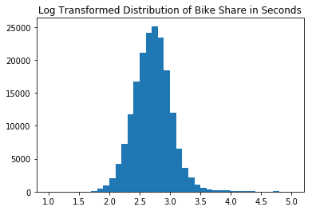

```python
# Lets plot a histogram depicting the duration_log
bins = np.arange(1, duration_log.max()+0.1, 0.1)

plt.hist(data = duration_log, x = duration_log, bins=bins);
plt.title("Log Transformed Distribution of Bike Share in Seconds");
```

```python
# Since I intend to generate a lot of scatter plots, lets generate a function

def myCountPlot(df,xVar):

    #set plot dimensions
    plt.figure (figsize = [8,8])

    #Set color
    base_color = sb.color_palette()[0]
    #plot
    sb.countplot(data=df,x=xVar,color=base_color);

    #Add title and format it
    plt.title(f'''Distribution of {xVar}'''.title(), fontsize=14, weight='bold')

    #Add x label and format it
    plt.xlabel(xVar.title(), fontsize=10, weight='bold')

    #Add y label and format it
    plt.ylabel('Frequency'.title(), fontsize=10, weight='bold')
```

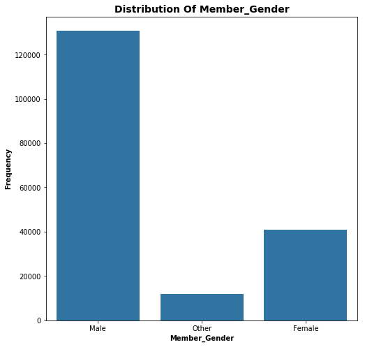

```python
# Lets now plot a bar graph of the member_genders from the dataset.

myCountPlot(bike_df, "member_gender" )
```

We can tell that the male gender has the highest counts depicting how frequently they use the bikes. The count is later followed by the female gender and eventually the others whose genders was not specified or included in the dataset.

Let's also have a closer look about the user_type using a bar graph.

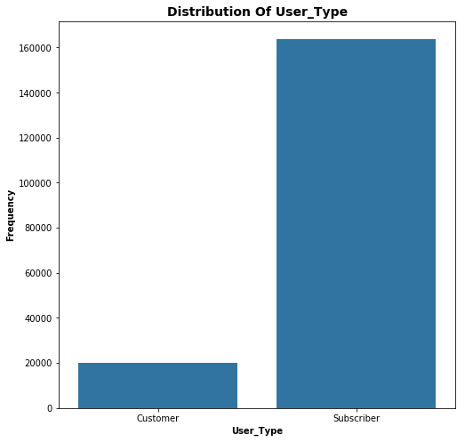

```python
# Lets now plot a bar graph of the user_type from the dataset.
myCountPlot(bike_df, "user_type" )
```

It appears that the number of subscribers that use the bikes are more than the customers.

Lets also have a good picture on the start_weekdays using a bar graph.

```python
days_of_week = bike_df['start_date'].dt.day_name()

bike_df['start_weekday'] = bike_df['start_date'].dt.day_name()
bike_df['end_weekday'] = bike_df['end_date'].dt.day_name()
bike_df.start_weekday.unique()
```

```
array(['Thursday', 'Wednesday', 'Tuesday', 'Monday', 'Sunday', 'Saturday',
       'Friday'], dtype=object)
```

```python
# convert start_weekday and end_weekday into ordered categorical types
ordinal_var_dict = {'start_weekday': ['Sunday','Monday','Tuesday','Wednesday','Thursday', 'Friday', 'Saturday'],
                    'end_weekday': ['Sunday','Monday','Tuesday','Wednesday','Thursday', 'Friday', 'Saturday']}

for var in ordinal_var_dict:
    ordered_var = pd.api.types.CategoricalDtype(ordered = True,
                                                categories = ordinal_var_dict[var])
    bike_df[var] = bike_df[var].astype(ordered_var)
```

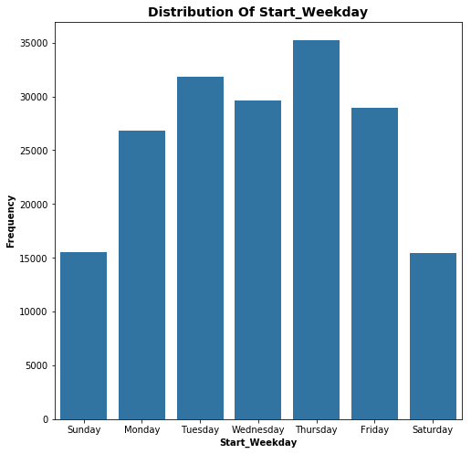

```python
#Now lets plot the distribution of the Start_Weekday

myCountPlot(bike_df, "start_weekday" )
```

According to the bar chart above, Thursday signifies a large influx of bikes used. Therefore, it seems a lot of people in the Bay region use the bikes more often on Thursdays than any other day of the week. Saturdays and Sundays having the least bike usage. We will dive deeper and see if this is the case.

Now that we know the start_weekday lets also have the end_weekday and see the relationship.

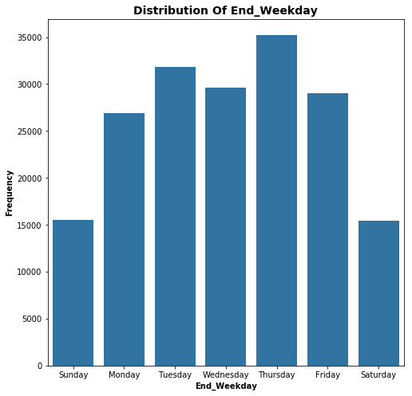

```python
#Now lets plot the distribution of th end_Weekday

myCountPlot(bike_df, "end_weekday" )
```

So it seems the projection is the same and the end_weekday that is very busy is on Thursday, followed by Tuesday, Wednesday, Friday, Monday and eventually Sunday and Saturday.

### Discuss the distribution(s) of your variable(s) of interest. Were there any unusual points? Did you need to perform any transformations?

> The distribution variable took on a large range of values, so I looked at the data using a log transform. Under the transformation, the data looked unimodal, with the highest numbers are between 100 seconds (1 min, 40 sec) and 1000 seconds (16 min, 40 sec).

### Of the features you investigated, were there any unusual distributions? Did you perform any operations on the data to tidy, adjust, or change the form of the data? If so, why did you do this?

> When investigating the dataset variables, a number of data wrangling had to be done to try and clean up the dataset. The task list included;
> 1. Change start and end times to date time.
> 2. Get the data, time, and day of the week into seperate columns (I will have to change the original column title from time to time_stamp).
> 3. Fill in the Nan values in the member_gender column.
> 4. Create a dataframe with the station data (for easy look up of data).

> All of these tasks were performed from the dataset to be able to move forward.

## Bivariate Exploration

> To start off with, I want to look at the pairwise correlations present between features in the data.

```python
# lets plot a scatterplot to see the relationship between 2 quantitative variables, the duration_sec and the age of the riders.
```

```python
# Since we have the member_birth_years, let's find their ages for easy visualization.

# First let's drop the unique birthvalue -9223372036854775808 which must have been filled in mistakenly.

bike_df = bike_df[bike_df.member_birth_year !=-9223372036854775808]

bike_df['member_birth_year'].value_counts()
```

```
1988.0    10236
1993.0     9325
1989.0     8972
1990.0     8658
1991.0     8498
1992.0     8250
1987.0     8018
1986.0     7973
1994.0     7660
1995.0     7423
1985.0     7028
1984.0     6562
1983.0     5954
1980.0     5024
1982.0     4990
1996.0     4640
1981.0     4345
1979.0     3756
1997.0     3481
1998.0     3208
1978.0     2830
1977.0     2725
1974.0     2633
1999.0     2528
1975.0     2503
1976.0     2442
1973.0     2080
1968.0     1928
1971.0     1924
1972.0     1909
          ...
1954.0      301
1952.0      189
1951.0      180
1950.0      178
1953.0      158
1947.0      135
1955.0      134
1945.0      105
1949.0       99
1931.0       89
1900.0       53
1948.0       51
2001.0       34
1943.0       30
1942.0       21
1933.0       20
1946.0       19
1902.0       11
1939.0       11
1941.0        9
1901.0        6
1938.0        3
1920.0        3
1934.0        2
1944.0        2
1930.0        1
1910.0        1
1927.0        1
1928.0        1
1878.0        1
Name: member_birth_year, Length: 75, dtype: int64
```

```python
col = bike_df['member_birth_year']

bike_df['age'] =2022 -  bike_df['member_birth_year']
```

```python
bike_df.sample(5)
```

|  | duration_sec | start_timestamp | end_timestamp | start_station_id | start_station_name | start_station_latitude | start_station_longitude | end_station_id | end_station_name | end_station_latitude | ... | user_type | member_birth_year | member_gender | start_date | start_time | start_weekday | end_date | end_time | end_weekday | age |
| --- | --- | --- | --- | --- | --- | --- | --- | --- | --- | --- | --- | --- | --- | --- | --- | --- | --- | --- | --- | --- | --- |
| 157884 | 775 | 2019-02-05 20:13:38.451 | 2019-02-05 20:26:34.277 | 350.0 | 8th St at Brannan St | 37.771431 | -122.405787 | 139.0 | Garfield Square (25th St at Harrison St) | 37.751017 | ... | Subscriber | 1995.0 | Male | 2019-02-05 | 20:13:38.451000 | Tuesday | 2019-02-05 | 20:26:34.277000 | Tuesday | 27.0 |
| 13284 | 390 | 2019-02-27 16:32:07.431 | 2019-02-27 16:38:37.531 | 126.0 | Esprit Park | 37.761634 | -122.390648 | 81.0 | Berry St at 4th St | 37.775880 | ... | Subscriber | 1987.0 | Female | 2019-02-27 | 16:32:07.431000 | Wednesday | 2019-02-27 | 16:38:37.531000 | Wednesday | 35.0 |
| 78919 | 166 | 2019-02-18 18:28:53.917 | 2019-02-18 18:31:40.038 | 150.0 | Adeline St at 40th St | 37.831277 | -122.278267 | 213.0 | 32nd St at Adeline St | 37.823847 | ... | Subscriber | 1991.0 | Male | 2019-02-18 | 18:28:53.917000 | Monday | 2019-02-18 | 18:31:40.038000 | Monday | 31.0 |
| 111264 | 253 | 2019-02-12 17:18:24.039 | 2019-02-12 17:22:37.616 | 223.0 | 16th St Mission BART Station 2 | 37.764765 | -122.420091 | 120.0 | Mission Dolores Park | 37.761420 | ... | Subscriber | 1980.0 | Female | 2019-02-12 | 17:18:24.039000 | Tuesday | 2019-02-12 | 17:22:37.616000 | Tuesday | 42.0 |
| 109666 | 611 | 2019-02-12 18:43:10.511 | 2019-02-12 18:53:21.720 | 22.0 | Howard St at Beale St | 37.789756 | -122.394643 | 92.0 | Mission Bay Kids Park | 37.772301 | ... | Subscriber | 1986.0 | Male | 2019-02-12 | 18:43:10.511000 | Tuesday | 2019-02-12 | 18:53:21.720000 | Tuesday | 36.0 |

5 rows × 22 columns

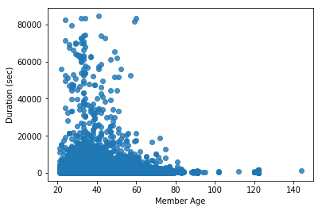

```python
# Now lets plot the scatterplot.

sb.regplot(data = bike_df, x = 'age', y = 'duration_sec', fit_reg= False );
plt.xlabel('Member Age')
plt.ylabel('Duration (sec)');
```

According to the above scatter plot, it is evident that most people who are from the ages of 20 to 60 years tend to ride bikes more and most of them concentrate to an average of 0 to 20000 counts.

Now lets try and jitter the scatterplot to have a clearer visual on the relationship between duration and the member birth year.

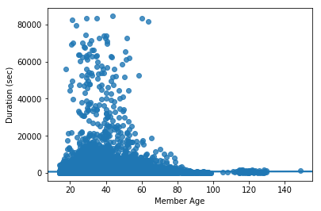

```python
sb.regplot(data = bike_df, x = 'age', y = 'duration_sec', x_jitter= 8 );
plt.xlabel('Member Age')
plt.ylabel('Duration (sec)');
```

We can now see a better distribution of the age between 20 years to slightly above 60 years, the value_count is raising above the 20000 mark hence signifying that bike share market category is to the youth in the San-Francisco Bay area. There are also a number of outliers of people who are above 80 years which I believe is as a result of the riders who did not fill in their birth year or the birth years where filled in incorrectly due to human error.

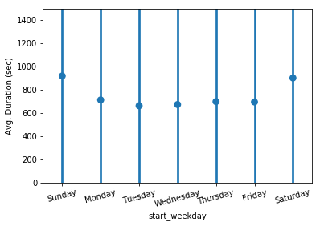

```python
# Lets plot an adaptive barplot and pointplot barchart to see how the average duration_sec relates to the start_weekdays

sb.pointplot(data= bike_df, x = 'start_weekday', y = 'duration_sec', ci='sd', linestyles = "" );
plt.xticks(rotation = 15)
plt.ylim([0, 1500])
plt.ylabel('Avg. Duration (sec)');
```

Having introduced the start_weekday bar graph in the univariate variables, Thursday seemed to be the busiest day of the week. In this adaptive bar plot that we have just plotted opposes the case and states that the average duration time is more pronounced on the weekends which is on Saturday and Sunday with an average duration time of 950 seconds. The least is on Tuesday with an average duration time of 650 seconds.

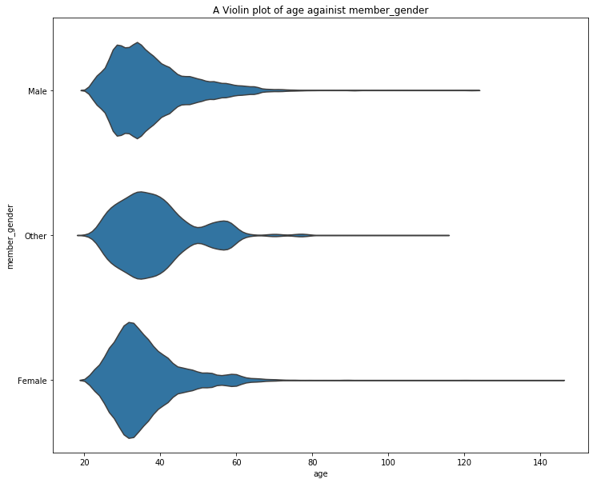

```python
# Now lets plot a Violin plot to see the relationships between a qualitative and a quantitative variable; the member_gender and the age

plt.figure(figsize=(12,10))
base_color = sb.color_palette()[0]
plt.title('A Violin plot of age againist member_gender')
sb.violinplot(data= bike_df, y='member_gender', x='age', color=base_color, inner=None);
```

Oops! the violin plot doesn't seem to have a clear visual of the age againist the member_gender though we can tell that both genders range from age 20 to 60 years.

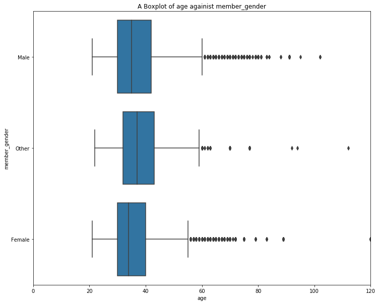

```python
# Now lets try ploting a boxplot of the same variables as our previous violin plot
plt.figure(figsize=(12,10))
plt.xlim([0, 120])
plt.title('A Boxplot of age againist member_gender')
base_color = sb.color_palette()[0]
sb.boxplot(data= bike_df, y='member_gender', x='age', color=base_color);
```

From the violin and the boxplot above we can deduct that the genders both male and female together with the others are mostly 20-60 years old. The minimum age of the member genders in both male and female is 20 years. The maximum ages are ranging at 56-60 years, and the median of the ages are ranging at 30-39 years. There are a number of outliers indicating some bike riders who are over 100 years and they must be quite elderly. The big reason again is due to human error while filling in the ages or the rider decided not to provide his/her year of birth.

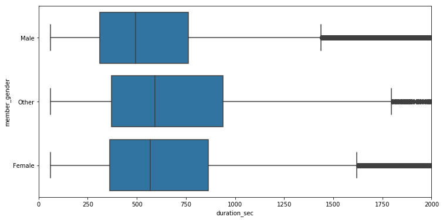

```python
# Lets also try plotting a boxplot to show the relationship between the member_gender and the duration_sec.
plt.figure(figsize=(12,6))
plt.xlim([0, 2000])
base_color = sb.color_palette()[0]
sb.boxplot(data= bike_df, y='member_gender', x='duration_sec', color=base_color);
```

The 'other' variable in the member_gender seem to be having the highest maximum duration in seconds of the bike time used followed by the female and finally the male gender. The median duration in seconds is significantly higher in the female gender as compared to the male gender and the same applies to the 1st and 2nd quartile.

Generally, if we compare the female to male gender, the female gender had a higher cycling duration time than the male gender.

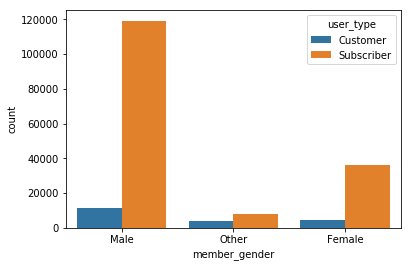

```python
#Now lets plot a clustered bar chart to show the relationship between the user_type and the member_gender.

sb.countplot(data = bike_df, x = 'member_gender', hue = 'user_type');
```

Acording to the clustered bar chart, the male gender has a higher customer and subscriber value count more than the female and the 'other' in the member_gender. Therefore, the male gender tend to be the best gender to target the Fordbike market share in terms of capitalizing on maximum profits.

### Talk about some of the relationships you observed in this part of the investigation. How did the feature(s) of interest vary with other features in the dataset?

> The duration has also corelated with the categorical variable, 'start weekday'. The weekends had the highest duration in which the Fordbikes were used. Saturday and Sunday had an average duration time of 950 seconds. The least was on Tuesday with an average duration time of 650 seconds.

### Did you observe any interesting relationships between the other features (not the main feature(s) of interest)?

> The same relationship that the start_weekday has is the same effect that the end_weekday has. Therefore, we will just pick one categorical variable from the two which is the start_weekday and not explore further with the end_weekday.

## Multivariate Exploration

> The main thing I want to explore in this part of the analysis is how the three categorical measures of start_weekday, user_type, member_gender play into the relationship between duration and age.

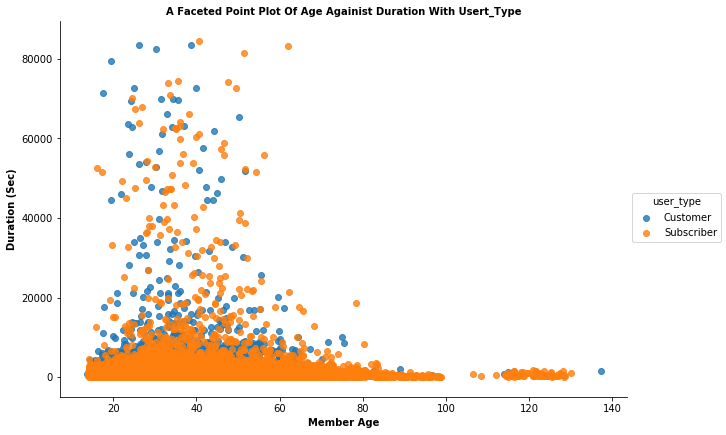

```python
#lets plot a multivariate scatter plot to show the recemblance between the duration, member_age and the user_type.

g = sb.FacetGrid(data = bike_df, hue = 'user_type',
                 hue_order = ['Customer', 'Subscriber'],size = 6, aspect= 1.5)

g.map(sb.regplot, 'age', 'duration_sec', x_jitter= 8, fit_reg = False);
g.add_legend()
plt.title('A Faceted Point Plot Of Age Againist Duration With Usert_type'.title(), fontsize=10, weight='bold')
plt.xlabel('Member Age'.title(), fontsize=10, weight='bold')
plt.ylabel('Duration (sec)'.title(), fontsize=10, weight='bold');
```

The scatterplot depicts that subscribers are more than the customers. Most subscribers are from the ages 15 years to 80 years and most of them have a bike duration time of 120 to 15000 seconds. Besides the customers being lesser in the numbers, the bigger number ranges between 15 years and 80 years.

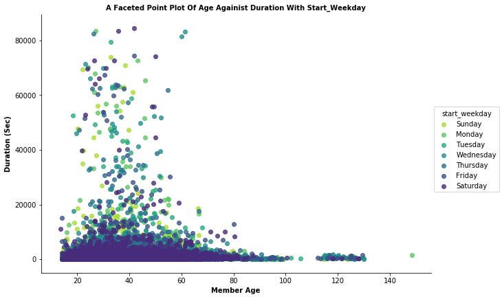

```python
# Now let's plot an odered variable and see the correlation between the duration_sec, member_age and the start_weekday

g = sb.FacetGrid(data = bike_df, hue = 'start_weekday',
                 palette= 'viridis_r', size = 6, aspect= 1.5)

g.map(sb.regplot, 'age', 'duration_sec', x_jitter= 8, fit_reg = False);
g.add_legend()
plt.title('A Faceted Point Plot Of Age Againist Duration With Start_Weekday'.title(), fontsize=10, weight='bold')
plt.xlabel('Member Age'.title(), fontsize=10, weight='bold')
plt.ylabel('Duration (sec)'.title(), fontsize=10, weight='bold');
```

From the scatter plot, the weekends (Saturday and Sunday) are quite busy with most of the bike riders ranging from the age of 15 years to around 70 years of age and a duration time of not more than 16000 seconds.

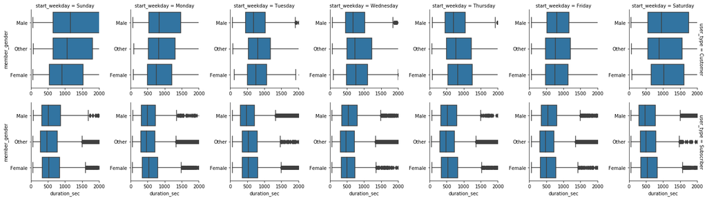

```python
# Lets dive a little deeper and have a magnified look on the correlation between the start_weekday, user_type, duration_sec, andthe member_gender.

# For this we will plot a double rowed faceted boxplot with the user_type depicting the rows.

g = sb.FacetGrid(data = bike_df, col = 'start_weekday', row = 'user_type', margin_titles = True)
plt.xlim([0, 2000])
g.map(sb.boxplot, 'duration_sec', 'member_gender');
```

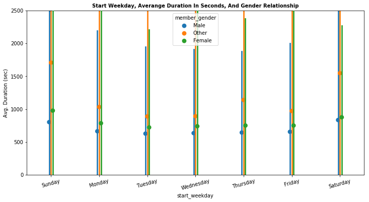

```python
# Lets plot an adaptive pointplot to see how the average duration_sec relates to the start_weekdays and the member_gender.

plt.figure(figsize=(12,6))
sb.pointplot(data= bike_df, x = 'start_weekday', y = 'duration_sec', hue = 'member_gender',
             ci='sd', linestyles = "", dodge = True);
plt.xticks(rotation = 15)
plt.title( 'Start Weekday, Averange Duration in Seconds, and Gender Relationship'.title(), fontsize=10, weight='bold')
plt.ylim([0, 2500])
plt.ylabel('Avg. Duration (sec)');
```

[output not shown]

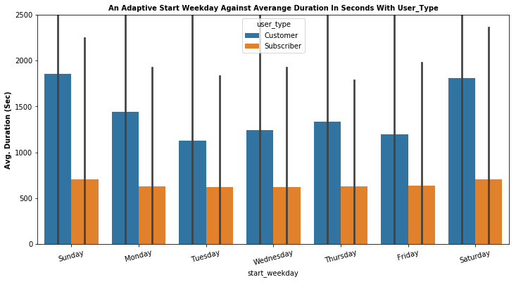

```python
# Now lets see how the user_type correlates with the start_weekday, and the duration_sec using an adaptive barchart.

plt.figure(figsize=(12,6))
sb.barplot(data= bike_df, x = 'start_weekday', y = 'duration_sec', hue = 'user_type',
             ci='sd');
plt.xticks(rotation = 15)
plt.title( 'An adaptive Start Weekday Against Averange Duration in Seconds With User_type'.title(), fontsize=10, weight='bold')
plt.ylim([0, 2500])
plt.ylabel('Avg. Duration (sec)'.title(), fontsize=10, weight='bold')
```

The adaptive barchart shows that the day with the highest average duration time was on Sunday with the highest user_type being the customers.Tuesday again had the lowest average time duration amongest the customers. The subscribers also had the highest average duration time on Sunday and Saturday with an almost equal average duration time across all the other days.

### Talk about some of the relationships you observed in this part of the investigation. Were there features that strengthened each other in terms of looking at your feature(s) of interest?

> I extended my investigation of the duration against the days of the week, ages, and the user_type in this section by looking at the impact of the categorical features. The multivariate exploration here showed that there indeed is a positive effect of the female members gender on the bike share duration, but in the dataset, this is initially hidden by the fact that the highest number of both the subscribers and the customers are from the male gender. Besides the female gender being lesser in numbers, they contributed to a higher duration time than the male gender. The days of the week also signified a larger impact on the weekends (Saturday and Sunday) with a lower duration time in the weekdays, both in the user_type and also among the members gender, hence placing Saturday and Sunday as the best days for profit gains.

### Were there any interesting or surprising interactions between features?

> Looking back at the boxplot the female gender played a bigger part in terms of the time duration than the expected male gender as it reflected earlier in the univariate exploration.